# 3.7 Exercises

7. Now suppose we obtain one additional observation, which was unfortunately mismeasured.

   ```
   > x1=c(x1, 0.1)
   > x2=c(x2, 0.8)
   > y=c(y,6)
   ```

```r
x1 = c(x1, 0.1)
x2 = c(x2, 0.8)
y  = c(y,  6.0)
```

Re-fit the linear models from (c) to (e) using this new data. What effect does this new observation have on each of the models? In each model, is this observation an outlier? A high-leverage point? Both? Explain your answers.

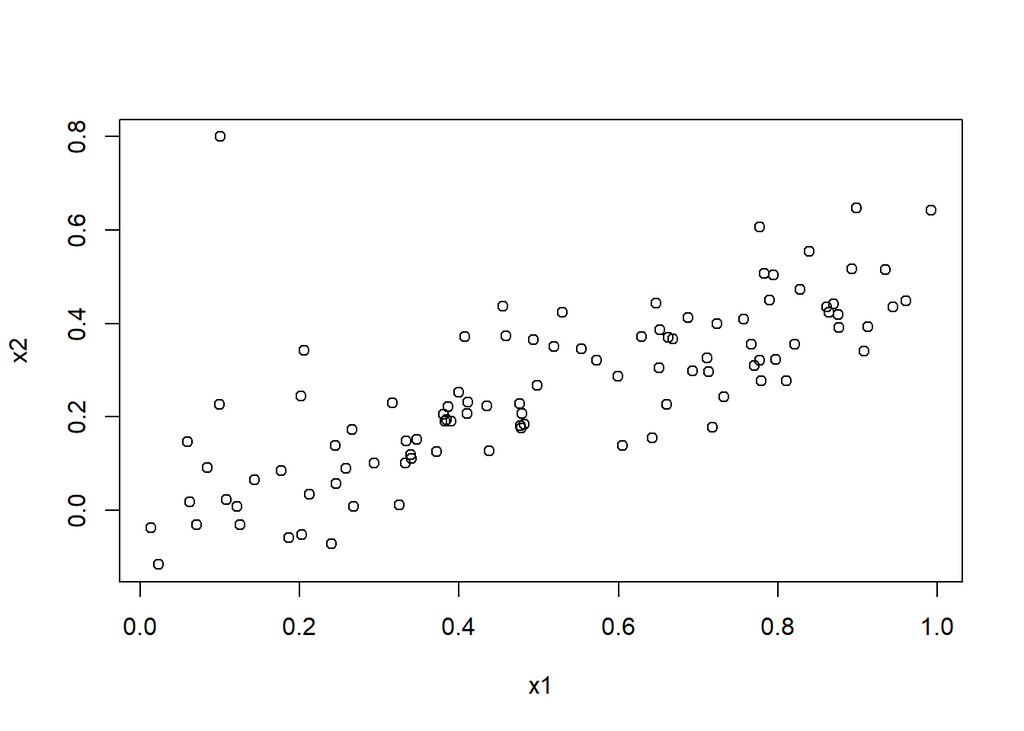

```r
plot(x1, x2)
```

*From the scatterplot, we can tell that the new observation is definitely a high leverage point, since it does not follow the pattern of all the other points. Also, it does not follow the original equation for the* x1-x2 *relationship:* $x2 = \frac{1}{2} x1 + \epsilon$. *Instead of being half the value of* x1, *the value of* x2 *is eight times the value! This either is a very high epsilon or evidence that the original relationship that we had supposed between* x1 *and* x2 *is not actually their true relationship. Deciding which is the case can be very important for producing reliable results.*

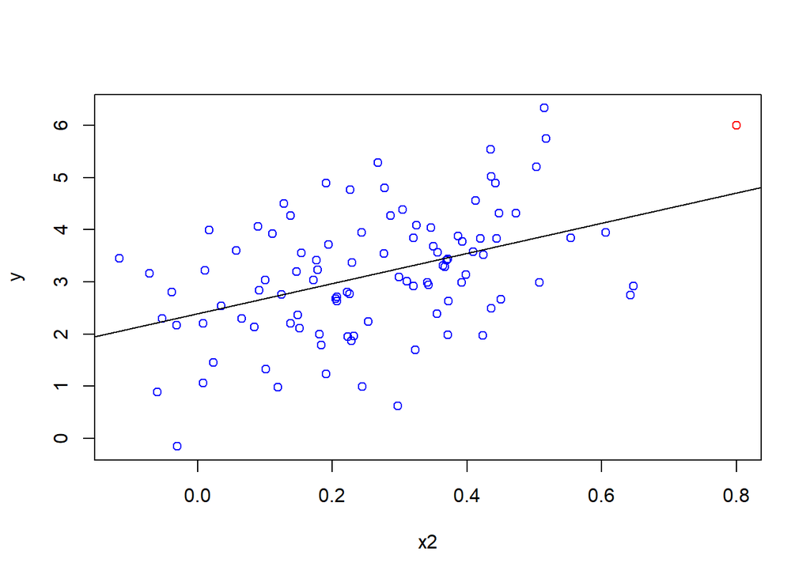

```r
plot(x2, y, col='blue')
abline(lm.fit2)
points(x2[101], y[101], col='red')
```

*From this plot, the new observation doesn’t appear to be much of an outlier.*

```r
lm.fit3 = lm(y~x1+x2)
summary(lm.fit3)
```

```
##
## Call:
## lm(formula = y ~ x1 + x2)
##
## Residuals:
##      Min       1Q   Median       3Q      Max
## -2.73348 -0.69318 -0.05263  0.66385  2.30619
##
## Coefficients:
##             Estimate Std. Error t value Pr(>|t|)
## (Intercept)   2.2267     0.2314   9.624 7.91e-16 ***
## x1            0.5394     0.5922   0.911  0.36458
## x2            2.5146     0.8977   2.801  0.00614 **
## ---
## Signif. codes:  0 '***' 0.001 '**' 0.01 '*' 0.05 '.' 0.1 ' ' 1
##
## Residual standard error: 1.075 on 98 degrees of freedom
## Multiple R-squared:  0.2188, Adjusted R-squared:  0.2029
## F-statistic: 13.72 on 2 and 98 DF,  p-value: 5.564e-06
```

*Interestingly, the fit using the new observation point now has a low enough p-value to reject the null hypothesis for* $\hat{\beta_2}$, *but not for* $\hat{\beta_1}$. *Also, in a fashion similar to the result from part (e), most of the* x1 *contribution to the predictor value is being “explained” by the* $\hat{\beta_2}$ *value.*

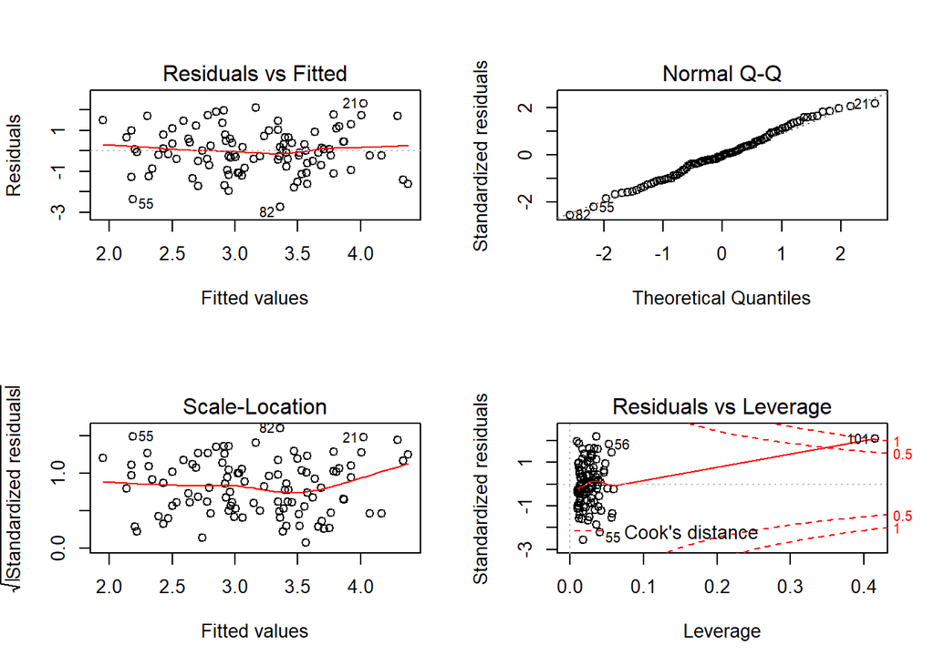

```r
par(mfrow=c(2,2))
plot(lm.fit3)
```

*Looking at these plots, we may reconfirm that the new observation is not an outlier, but it is a high leverage point. This new model does make a good fit to the training data and can be considered close to the true relationship in terms of its ability to predict the response value, but the equation for the model is not actually that close to the true equation used to produce* y.

# Exercise 15

This problem involves the **Boston** dat set, which we saw in the lab for this chapter. We will now try to predict per capita crime rate using the other variables in this data set. In other words, per capita crime rate is the response, and the other variables are the predictors.

```r
library(MASS)
?Boston
```

1. For each predictor, fit a simple linear regression model to predict the response. Describe your results. In which of the models is there a statistically significant association between the predictor and the response? Create some plots to back up your assertions.

```r
for (predictor in names(Boston)) {
  if (predictor != 'crim') {
    print(predictor)
    # Display the p-value for the estimated slope of the fit
    print(coefficients(summary(lm(formula = as.formula(paste("crim ~ ", predictor)), data = Boston)))[2,4])
  }
}
```

```
## [1] "zn"
## [1] 5.506472e-06
## [1] "indus"
## [1] 1.450349e-21
## [1] "chas"
## [1] 0.2094345
## [1] "nox"
## [1] 3.751739e-23
## [1] "rm"
## [1] 6.346703e-07
## [1] "age"
## [1] 2.854869e-16
## [1] "dis"
## [1] 8.519949e-19
## [1] "rad"
## [1] 2.693844e-56
## [1] "tax"
## [1] 2.357127e-47
## [1] "ptratio"
## [1] 2.942922e-11
## [1] "black"
## [1] 2.487274e-19
## [1] "lstat"
## [1] 2.654277e-27
## [1] "medv"
## [1] 1.173987e-19
```

zn, indus, nox, rm, age, dis, rad, tax, ptratio, black, lstat, *and* medv *all have a low enough p-value to reject the null hypothesis for a simple linear regression with* crim. *That is all of the predictors in the* Boston *data except for* chas.

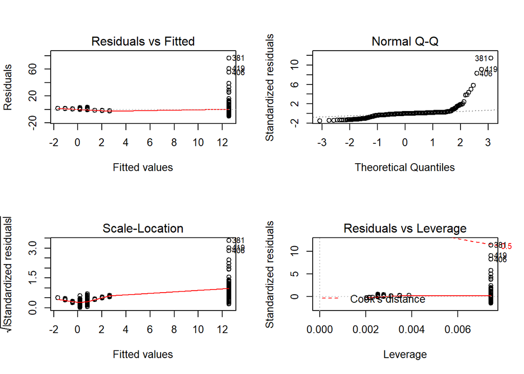

```r
lm.rad = lm(crim ~ rad, data = Boston)
lm.tax = lm(crim ~ tax, data = Boston)
lm.ptratio = lm(crim ~ ptratio, data = Boston)
par(mfrow=c(2,2))
plot(lm.rad)
```

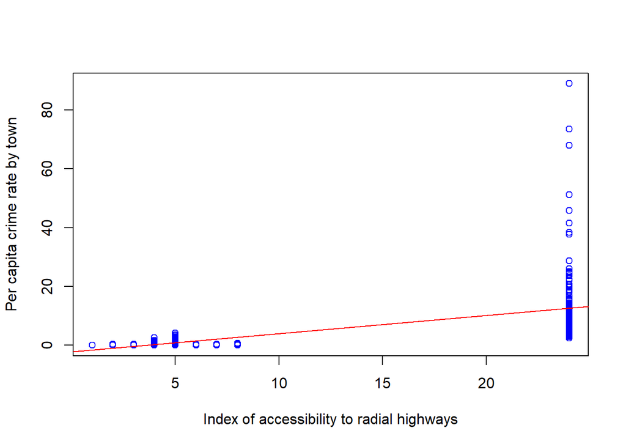

```r
plot(Boston$rad, Boston$crim, xlab='Index of accessibility to radial highways', ylab='Per capita crime rate by town', col='blue')
abline(lm.rad, col='red')
```

*From the plots, it is obvious that a linear regression here is a terrible fit. Understanding the very limited amount of values that* rad *can take on also suggests that a linear regression might not be ideal. Despite the low p-value of the fit, we may conclude from our training data that there is not a simple linear relationship between the index of accessibility to radial highways and the per capita crime rate of the town.*

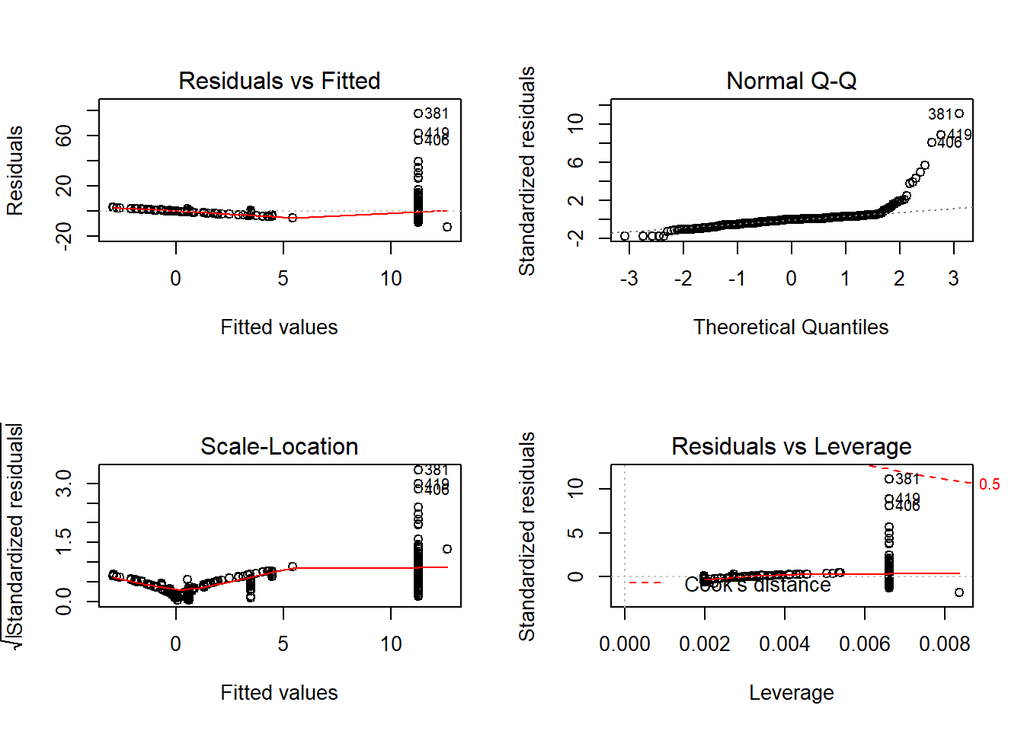

```r
par(mfrow=c(2,2))
plot(lm.tax)
```

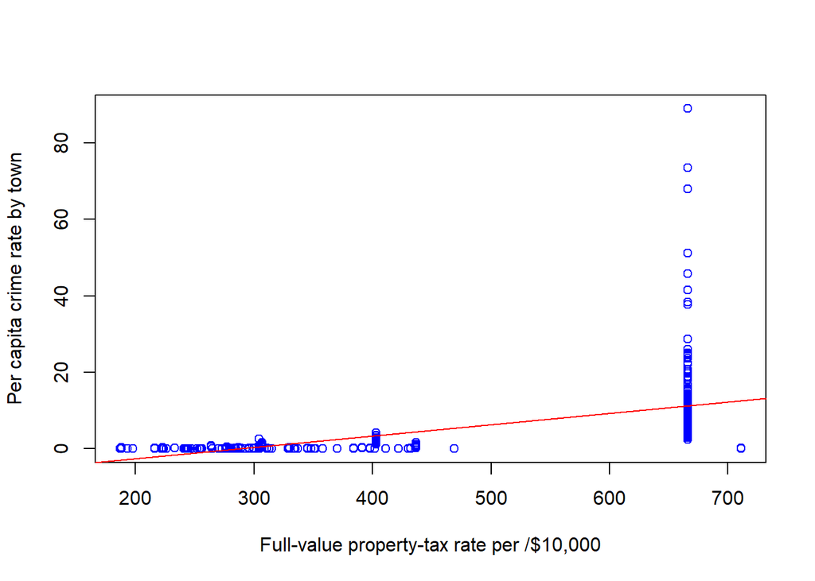

```r
plot(Boston$tax, Boston$crim, xlab='Full-value property-tax rate per /$10,000', ylab='Per capita crime rate by town', col='blue')
abline(lm.tax, col='red')
```

*Interestingly, the fit for the crime rate using the property-tax rate is very reminiscent of the fit using the index of accessibility to radial highways. In both fits, the relationship is clearly not linear, but the only towns with high crime rates also have a high predictor value. However, a high predictor value town is still much more likely to have a low per capita crime rate.*

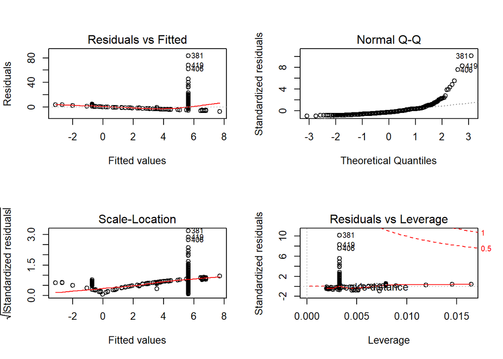

```r
par(mfrow=c(2,2))
plot(lm.ptratio)
```

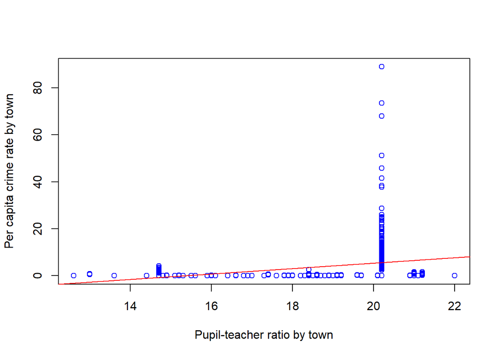

```r
plot(Boston$ptratio, Boston$crim, xlab='Pupil-teacher ratio by town', ylab='Per capita crime rate by town', col='blue')
abline(lm.ptratio, col='red')
```

2. Fit a multiple regression model to predict the response using all of the predictors. Describe your results. For which predictors can we reject the null hypothesis $H_0: \beta_j = 0$?

```r
lm.fit = lm(crim ~ ., data = Boston)
summary(lm.fit)
```

```
##
## Call:
## lm(formula = crim ~ ., data = Boston)
##
## Residuals:
##    Min     1Q Median     3Q    Max
## -9.924 -2.120 -0.353  1.019 75.051
##
## Coefficients:
##               Estimate Std. Error t value Pr(>|t|)
## (Intercept)  17.033228   7.234903   2.354 0.018949 *
## zn            0.044855   0.018734   2.394 0.017025 *
## indus        -0.063855   0.083407  -0.766 0.444294
## chas         -0.749134   1.180147  -0.635 0.525867
## nox         -10.313535   5.275536  -1.955 0.051152 .
## rm            0.430131   0.612830   0.702 0.483089
## age           0.001452   0.017925   0.081 0.935488
## dis          -0.987176   0.281817  -3.503 0.000502 ***
## rad           0.588209   0.088049   6.680 6.46e-11 ***
## tax          -0.003780   0.005156  -0.733 0.463793
## ptratio      -0.271081   0.186450  -1.454 0.146611
## black        -0.007538   0.003673  -2.052 0.040702 *
## lstat         0.126211   0.075725   1.667 0.096208 .
## medv         -0.198887   0.060516  -3.287 0.001087 **
## ---
## Signif. codes:  0 '***' 0.001 '**' 0.01 '*' 0.05 '.' 0.1 ' ' 1
##
## Residual standard error: 6.439 on 492 degrees of freedom
## Multiple R-squared:  0.454,  Adjusted R-squared:  0.4396
## F-statistic: 31.47 on 13 and 492 DF,  p-value: < 2.2e-16
```

*Using a threshold of 1%, we may reject the null hypothesis for the* dis, rad, *and* medv *predictors. This is a much smaller subset of predictors than we saw when using simple linear regressions. Also, of the three predictors with the lowest p-values from the simple linear regressions, only one may reject the null hypothesis here.*

3. How do your results from (a) compare to your results from (b)? Create a plot displaying the univariate regression coefficients from (a) on the *x*-axis and the multiple regression coefficients from (b) on the *y*-axis. That is, each predictor is displayed as a single point in the plot. Its coefficient in a simple linear regression model is shown on the *x*-axis, and its coefficient estimate in the multiple linear regression model is shown on the *y*-axis.

```r
df = data.frame()
# Drop the first name b/c that's the Intercept
for (name in names(coef(lm.fit))[-1]){
  df = rbind(df, data.frame(name = name,
                            simple = coef(lm(formula = as.formula(paste("crim ~ ", name)), data = Boston))[name],
                            multiple = coef(lm.fit)[name]
                            ))
}
print(df)
```

```
##            name      simple      multiple
## zn           zn -0.07393498   0.044855215
## indus     indus  0.50977633  -0.063854824
## chas       chas -1.89277655  -0.749133611
## nox         nox 31.24853120 -10.313534912
## rm           rm -2.68405122   0.430130506
## age         age  0.10778623   0.001451643
## dis         dis -1.55090168  -0.987175726
## rad         rad  0.61791093   0.588208591
## tax         tax  0.02974225  -0.003780016
## ptratio ptratio  1.15198279  -0.271080558
## black     black -0.03627964  -0.007537505
## lstat     lstat  0.54880478   0.126211376
## medv       medv -0.36315992  -0.198886821
```

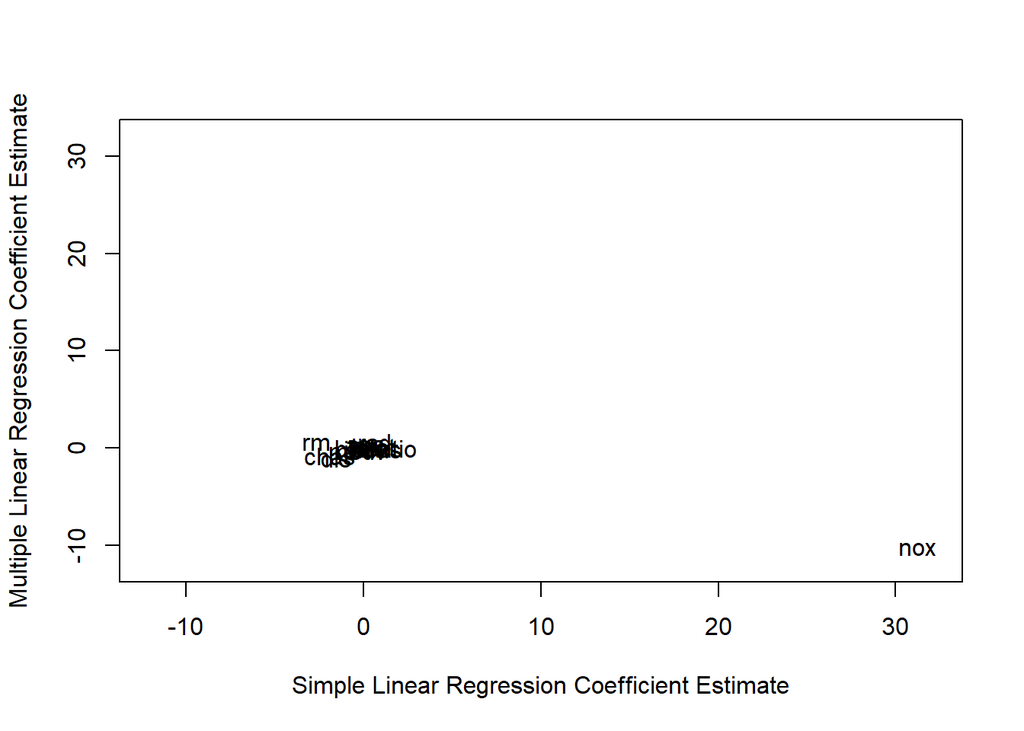

```r
plot(1, type='n', xlab = 'Simple Linear Regression Coefficient Estimate', ylab = 'Multiple Linear Regression Coefficient Estimate', xlim=c(-12,32), ylim=c(-12,32))
text(df$simple, df$multiple, df$name)
```

```r
#plot(df$simple, df$multiple, xlab = 'Simple Linear Regression Coefficient Estimate', ylab = 'Multiple Linear Regression Coefficient Estimate', xlim=c(-12,32), ylim=c(-12,32))
```

*The estimated coefficient for the* nox *predictor changed dramatically. In the simple linear regression, the model had an* **increase** *of 31 per capita crime rate in a town if it had one more part per 10 million of nitrogen oxides concentration. However, in the multiple linear regression, the estimated impact of one more part per 10 million is a* **decrease** *of 10 per capita crime rate in the town.*

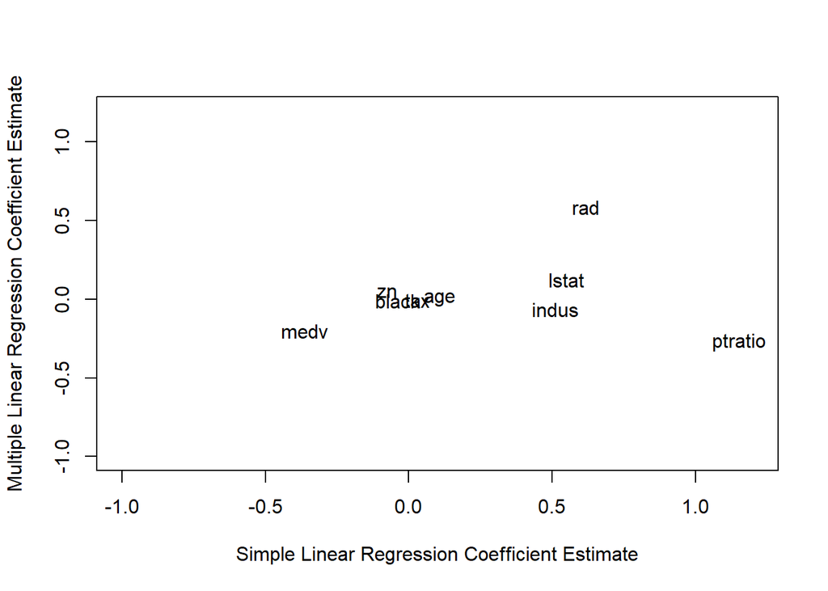

```r
subDf = df[which(df$name != 'nox'),]
plot(1, type='n', xlab = 'Simple Linear Regression Coefficient Estimate', ylab = 'Multiple Linear Regression Coefficient Estimate', xlim=c(-1,1.2), ylim=c(-1,1.2))
text(subDf$simple, subDf$multiple, subDf$name)
```

*None of the other coefficient estimates change quite as dramatically from the simple linear regression to the multiple linear regression. However, the* zn, indus, rm, tax, *and* ptratio *predictors all switch signs, either going from a negative slope to a positive slope or from a positive slope to a negative slope. Looking just at the* tax *and* ptratio *predictors, they both went from a positive estimated coefficient with a very low p-value in their simple linear regressions to a negative estimated coefficient with a very high p-value. These changes demonstrate just how important it is to carefully select what type of model to implement.*

4. Is there evidence of non-linear association between any of the predictors and the response? To answer this question, for each predictor X, fit a model of the form
   $$Y = \beta_0 + \beta_1 X + \beta_2 X^2 + \beta_3 X^3 + \epsilon$$
   .

```r
for (predictor in names(Boston)) {
  if (predictor != 'crim') {
    print(predictor)
    fit = lm(formula = as.formula(paste('crim ~ I(', predictor, '^3) + I(', predictor, '^2) + ', predictor)), data = Boston)
    # Display the p-values for the estimated slope of the fit
    print(coef(summary(fit)))
    print('XXXXXXXXXXXXXXXXXXXXXXXXXXXXXXXXXXXXXXX')
  }
}
```

```
## [1] "zn"
##                  Estimate   Std. Error   t value     Pr(>|t|)
## (Intercept)  4.846050e+00 4.329846e-01 11.192199 4.113000e-26
## I(zn^3)     -3.775793e-05 3.138615e-05 -1.203012 2.295386e-01
## I(zn^2)      6.482634e-03 3.860728e-03  1.679122 9.375050e-02
## zn          -3.321884e-01 1.098081e-01 -3.025171 2.612296e-03
## [1] "XXXXXXXXXXXXXXXXXXXXXXXXXXXXXXXXXXXXXXX"
## [1] "indus"
##                 Estimate   Std. Error   t value     Pr(>|t|)
## (Intercept)  3.662568279 1.5739833325  2.326942 2.036526e-02
## I(indus^3)  -0.006976009 0.0009566596 -7.292049 1.196405e-12
## I(indus^2)   0.251937298 0.0393221245  6.407011 3.420187e-10
## indus       -1.965212934 0.4819900578 -4.077289 5.297064e-05
## [1] "XXXXXXXXXXXXXXXXXXXXXXXXXXXXXXXXXXXXXXX"
## [1] "chas"
##              Estimate Std. Error   t value     Pr(>|t|)
## (Intercept)  3.744447  0.3961111  9.453021 1.239505e-19
## I(chas^3)   -1.892777  1.5061155 -1.256727 2.094345e-01
## [1] "XXXXXXXXXXXXXXXXXXXXXXXXXXXXXXXXXXXXXXX"
## [1] "nox"
##               Estimate Std. Error   t value     Pr(>|t|)
## (Intercept)   233.0866    33.6431  6.928214 1.311939e-11
## I(nox^3)    -1245.7029   149.2816 -8.344649 6.961110e-16
## I(nox^2)     2248.5441   279.8993  8.033404 6.811300e-15
## nox         -1279.3713   170.3975 -7.508159 2.758372e-13
## [1] "XXXXXXXXXXXXXXXXXXXXXXXXXXXXXXXXXXXXXXX"
## [1] "rm"
##               Estimate Std. Error    t value   Pr(>|t|)
## (Intercept) 112.624596  64.517236  1.7456513 0.08148335
## I(rm^3)      -0.174477   0.263747 -0.6615314 0.50857511
## I(rm^2)       4.550896   5.009862  0.9083875 0.36410939
## rm          -39.150136  31.311492 -1.2503440 0.21175641
## [1] "XXXXXXXXXXXXXXXXXXXXXXXXXXXXXXXXXXXXXXX"
## [1] "age"
##                  Estimate   Std. Error    t value    Pr(>|t|)
## (Intercept) -2.548763e+00 2.769140e+00 -0.9204168 0.357797077
## I(age^3)     5.745307e-05 2.109355e-05  2.7237266 0.006679915
## I(age^2)    -7.229596e-03 3.636995e-03 -1.9877935 0.047377328
## age          2.736531e-01 1.863796e-01  1.4682566 0.142660827
## [1] "XXXXXXXXXXXXXXXXXXXXXXXXXXXXXXXXXXXXXXX"
```

[output cut: 34 more lines]

```
## [1] "XXXXXXXXXXXXXXXXXXXXXXXXXXXXXXXXXXXXXXX"
## [1] "lstat"
##                  Estimate   Std. Error    t value   Pr(>|t|)
## (Intercept)  1.2009655812 2.0286451580  0.5920038 0.55411459
## I(lstat^3)  -0.0008573703 0.0005651667 -1.5170220 0.12989059
## I(lstat^2)   0.0557794159 0.0301156072  1.8521764 0.06458736
## lstat       -0.4490655872 0.4648911092 -0.9659586 0.33452999
## [1] "XXXXXXXXXXXXXXXXXXXXXXXXXXXXXXXXXXXXXXX"
## [1] "medv"
##                 Estimate   Std. Error    t value     Pr(>|t|)
## (Intercept) 53.165538094 3.3563105351  15.840471 3.989088e-46
## I(medv^3)   -0.001490103 0.0002037895  -7.311969 1.046510e-12
## I(medv^2)    0.155496490 0.0171904422   9.045520 3.260523e-18
## medv        -5.094830543 0.4338320525 -11.743785 2.637707e-28
## [1] "XXXXXXXXXXXXXXXXXXXXXXXXXXXXXXXXXXXXXXX"
```

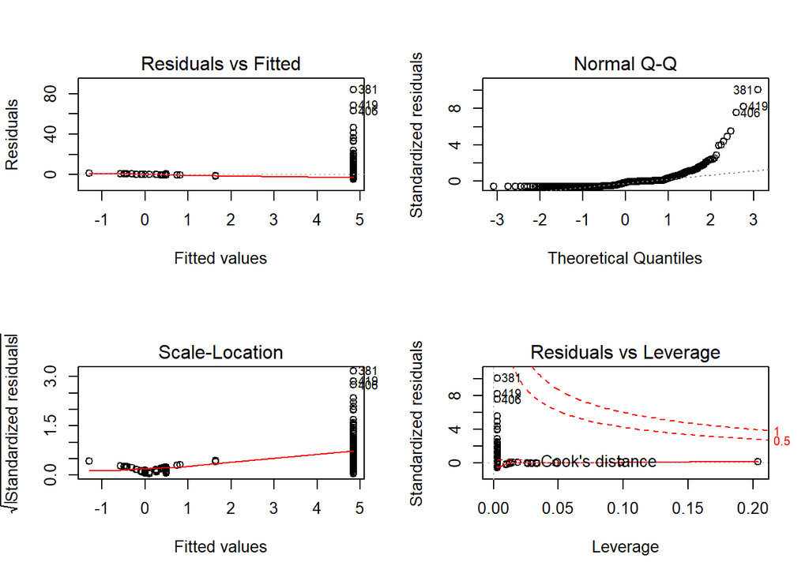

```r
lm.zn = lm(crim ~ I(zn^3) + I(zn^2) + zn, data = Boston)
lm.indus = lm(crim ~ I(indus^3) + I(indus^2) + indus, data = Boston)
lm.nox = lm(crim ~ I(nox^3) + I(nox^2) + nox, data = Boston)
lm.dis= lm(crim ~ I(dis^3) + I(dis^2) + dis, data = Boston)
lm.medv = lm(crim ~ I(medv^3) + I(medv^2) + medv, data = Boston)
par(mfrow = c(2,2))
plot(lm.zn)
```

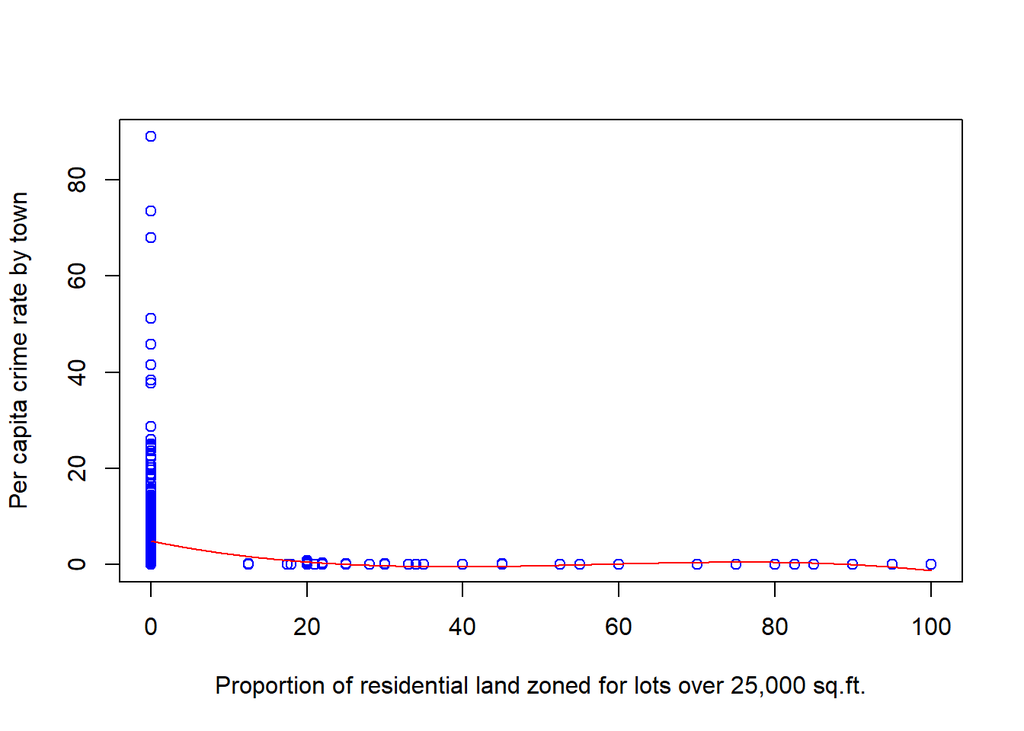

```r
plot(Boston$zn, Boston$crim, xlab = 'Proportion of residential land zoned for lots over 25,000 sq.ft.', ylab = 'Per capita crime rate by town', col='blue')
x = seq(from = min(Boston$zn), to = max(Boston$zn), length.out = 1000)
lines(x, predict(lm.zn, data.frame(zn = x)), col='red')
```